# Tugas Individu TPG Praktikum : Analisis Gerombol

Muth’iah Iffa Karimah

2025-11-06

# Input Data : Data World Happiness Record 2021 (kaggle)

```r
library(readr)
library(psych)
library(GPArotation)
library(factoextra)
library(dplyr)
library(cluster)
library(factoextra)
library(clusterCrit)
```

```r
library(ggplot2)
library(tidyr)
library(scales)
library(corrplot)
library(cluster)
```

```r
data = read_csv("D:\\Semester 5\\TPG\\TPG\\world-happiness-report-2021.csv")
str(data)
```

```
## spc_tbl_ [149 × 20] (S3: spec_tbl_df/tbl_df/tbl/data.frame)
##  $ Country name                              : chr [1:149] "Finland" "Denmark" "Switzerland" "Iceland" ...
##  $ Regional indicator                        : chr [1:149] "Western Europe" "Western Europe" "Western Europe" "Western Europe" ...
##  $ Ladder score                              : num [1:149] 7.84 7.62 7.57 7.55 7.46 ...
##  $ Standard error of ladder score            : num [1:149] 0.032 0.035 0.036 0.059 0.027 0.035 0.036 0.037 0.04 0.036 ...
##  $ upperwhisker                              : num [1:149] 7.9 7.69 7.64 7.67 7.52 ...
##  $ lowerwhisker                              : num [1:149] 7.78 7.55 7.5 7.44 7.41 ...
##  $ Logged GDP per capita                     : num [1:149] 10.8 10.9 11.1 10.9 10.9 ...
##  $ Social support                            : num [1:149] 0.954 0.954 0.942 0.983 0.942 0.954 0.934 0.908 0.948 0.934 ...
##  $ Healthy life expectancy                   : num [1:149] 72 72.7 74.4 73 72.4 73.3 72.7 72.6 73.4 73.3 ...
##  $ Freedom to make life choices              : num [1:149] 0.949 0.946 0.919 0.955 0.913 0.96 0.945 0.907 0.929 0.908 ...
##  $ Generosity                                : num [1:149] -0.098 0.03 0.025 0.16 0.175 0.093 0.086 -0.034 0.134 0.042 ...
##  $ Perceptions of corruption                 : num [1:149] 0.186 0.179 0.292 0.673 0.338 0.27 0.237 0.386 0.242 0.481 ...
##  $ Ladder score in Dystopia                  : num [1:149] 2.43 2.43 2.43 2.43 2.43 2.43 2.43 2.43 2.43 2.43 ...
##  $ Explained by: Log GDP per capita          : num [1:149] 1.45 1.5 1.57 1.48 1.5 ...
##  $ Explained by: Social support              : num [1:149] 1.11 1.11 1.08 1.17 1.08 ...
##  $ Explained by: Healthy life expectancy     : num [1:149] 0.741 0.763 0.816 0.772 0.753 0.782 0.763 0.76 0.785 0.782 ...
##  $ Explained by: Freedom to make life choices: num [1:149] 0.691 0.686 0.653 0.698 0.647 0.703 0.685 0.639 0.665 0.64 ...
##  $ Explained by: Generosity                  : num [1:149] 0.124 0.208 0.204 0.293 0.302 0.249 0.244 0.166 0.276 0.215 ...
##  $ Explained by: Perceptions of corruption   : num [1:149] 0.481 0.485 0.413 0.17 0.384 0.427 0.448 0.353 0.445 0.292 ...
##  $ Dystopia + residual                       : num [1:149] 3.25 2.87 2.84 2.97 2.8 ...
##  - attr(*, "spec")=
##   .. cols(
##   ..   `Country name` = col_character(),
##   ..   `Regional indicator` = col_character(),
##   ..   `Ladder score` = col_double(),
##   ..   `Standard error of ladder score` = col_double(),
##   ..   upperwhisker = col_double(),
##   ..   lowerwhisker = col_double(),
##   ..   `Logged GDP per capita` = col_double(),
##   ..   `Social support` = col_double(),
##   ..   `Healthy life expectancy` = col_double(),
##   ..   `Freedom to make life choices` = col_double(),
##   ..   Generosity = col_double(),
##   ..   `Perceptions of corruption` = col_double(),
##   ..   `Ladder score in Dystopia` = col_double(),
##   ..   `Explained by: Log GDP per capita` = col_double(),
##   ..   `Explained by: Social support` = col_double(),
##   ..   `Explained by: Healthy life expectancy` = col_double(),
##   ..   `Explained by: Freedom to make life choices` = col_double(),
##   ..   `Explained by: Generosity` = col_double(),
##   ..   `Explained by: Perceptions of corruption` = col_double(),
##   ..   `Dystopia + residual` = col_double()
##   .. )
##  - attr(*, "problems")=<externalptr>
```

```r
View(data)
```

# Eksplorasi Data

### Peubah Relevan

Memilih peubah yang relevan dengan sosial-politik-dan ekoonomi karena peubah seperti log GDP per kapita menunjukkan skor bukan peubah untuk penggerombolan.

```r
# Memilih peubah yang relevan
data_new <- data %>%
  select(`Country name`,
         `Logged GDP per capita`,
         `Social support`,
         `Healthy life expectancy`,
         `Freedom to make life choices`,
         `Generosity`,
         `Perceptions of corruption`)

# Lihat 6 baris pertama dari data baru kita
head(data_new)
```

```
## # A tibble: 6 × 7
##   `Country name` `Logged GDP per capita` `Social support` Healthy life expecta…¹
##   <chr>                            <dbl>            <dbl>                  <dbl>
## 1 Finland                           10.8            0.954                   72
## 2 Denmark                           10.9            0.954                   72.7
## 3 Switzerland                       11.1            0.942                   74.4
## 4 Iceland                           10.9            0.983                   73
## 5 Netherlands                       10.9            0.942                   72.4
## 6 Norway                            11.1            0.954                   73.3
## # ℹ abbreviated name: ¹`Healthy life expectancy`
## # ℹ 3 more variables: `Freedom to make life choices` <dbl>, Generosity <dbl>,
## #   `Perceptions of corruption` <dbl>
```

```r
View(data_new)
```

## Cek Missing Value

```r
# Menghitung jumlah data hilang di tiap kolom
colSums(is.na(data_new))
```

```
##                 Country name        Logged GDP per capita
##                            0                            0
##               Social support      Healthy life expectancy
##                            0                            0
## Freedom to make life choices                   Generosity
##                            0                            0
##    Perceptions of corruption
##                            0
```

Data sudah bersih, terlihat tidak ada missing value di tiap kolom

## Skala Peubah

Menjawab pertanyaan “Apakah perlu standarisasi?”

```r
data.num = data_new %>% select(-`Country name`) # Pengecualian kolom negara untuk dianalisis
summary(data.num) # Ringkasan statistik
```

```
##  Logged GDP per capita Social support   Healthy life expectancy
##  Min.   : 6.635        Min.   :0.4630   Min.   :48.48
##  1st Qu.: 8.541        1st Qu.:0.7500   1st Qu.:59.80
##  Median : 9.569        Median :0.8320   Median :66.60
##  Mean   : 9.432        Mean   :0.8147   Mean   :64.99
##  3rd Qu.:10.421        3rd Qu.:0.9050   3rd Qu.:69.60
##  Max.   :11.647        Max.   :0.9830   Max.   :76.95
##  Freedom to make life choices   Generosity       Perceptions of corruption
##  Min.   :0.3820               Min.   :-0.28800   Min.   :0.0820
##  1st Qu.:0.7180               1st Qu.:-0.12600   1st Qu.:0.6670
##  Median :0.8040               Median :-0.03600   Median :0.7810
##  Mean   :0.7916               Mean   :-0.01513   Mean   :0.7274
##  3rd Qu.:0.8770               3rd Qu.: 0.07900   3rd Qu.:0.8450
##  Max.   :0.9700               Max.   : 0.54200   Max.   :0.9390
```

## Outlier

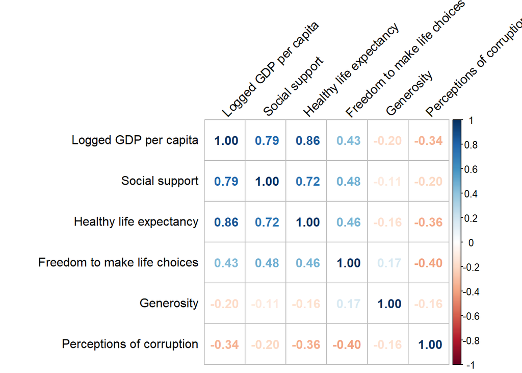

```r
# Matriks korelasi
corr = cor(data.num)

# Visualisasi
corrplot(corr, method = "number", tl.col = "black", tl.srt = 45)
```

Dalam data terlihat bahwa korelasi tertinggi antarpeubah adalah

1. **Helathy life expectancy - Logged GDP per capita = 0.86**
2. **Social support - Logged GDP per capita = 0.79**
3. **Healthy life expecancy - Social support = 0.72**

Artinya hasil matriks korelasi ini menunjukkan bahwa ada multikolinearitas pada data, perlu “membuang” salah satu peubah yang menyebabkan redudansi.

Di sini saya akan **membuang peubah “Healthy life expectancy”** karena peubah tersebut adalah hasil dari peubah “Logged GDP per capita” dan “Social support” yang mana kedua peubah ini adalah pendorong utama dari ekonomi dan sosial.

## Boxplot

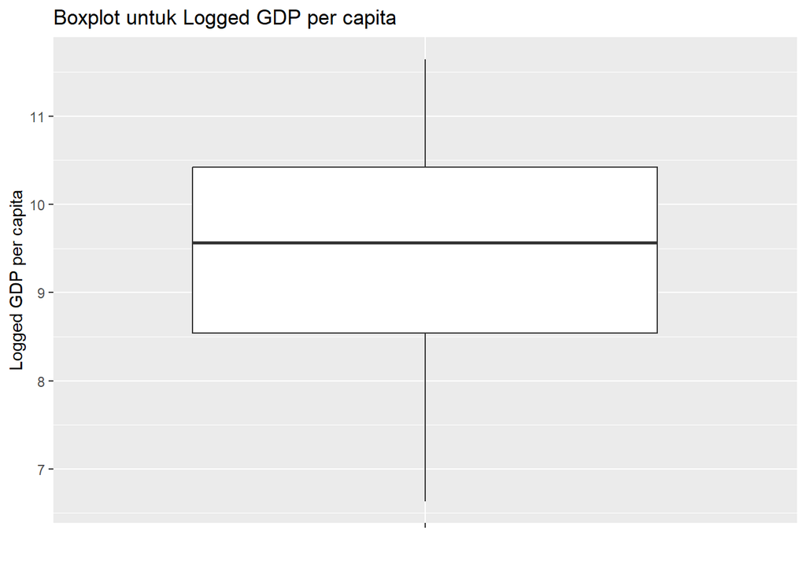

```r
# Logged GDP per capita
ggplot(data.num, aes(x = "", y = `Logged GDP per capita`)) +
  geom_boxplot() +
  labs(title = "Boxplot untuk Logged GDP per capita", x = "")
```

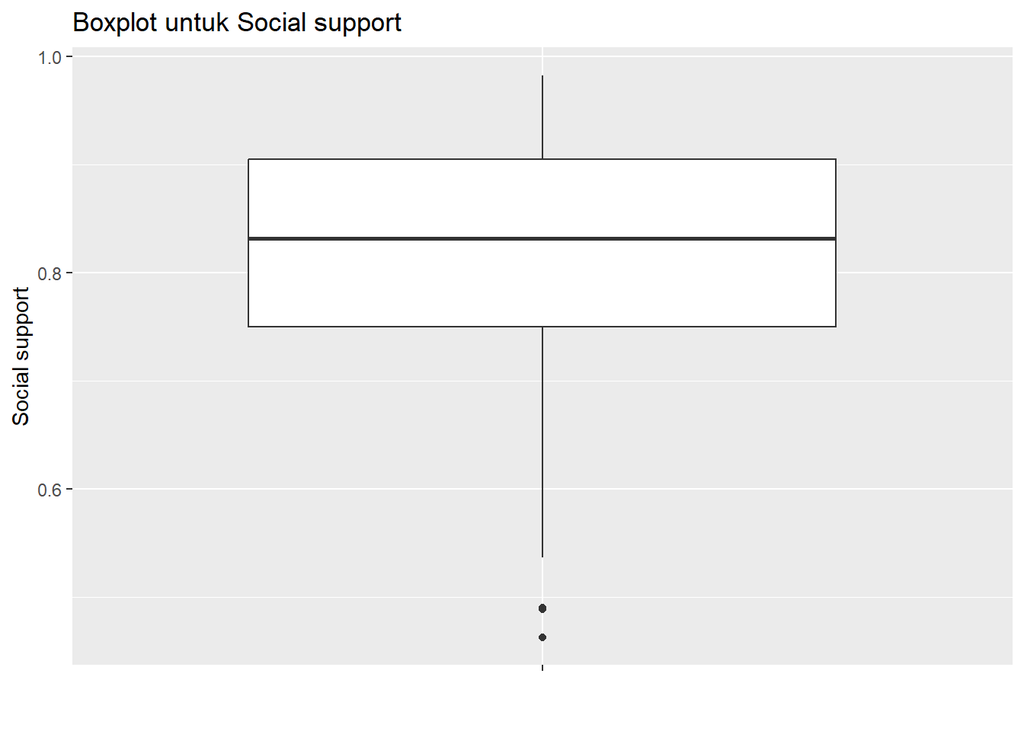

```r
# Social support
ggplot(data.num, aes(x = "", y = `Social support`)) +
  geom_boxplot() +
  labs(title = "Boxplot untuk Social support", x = "")
```

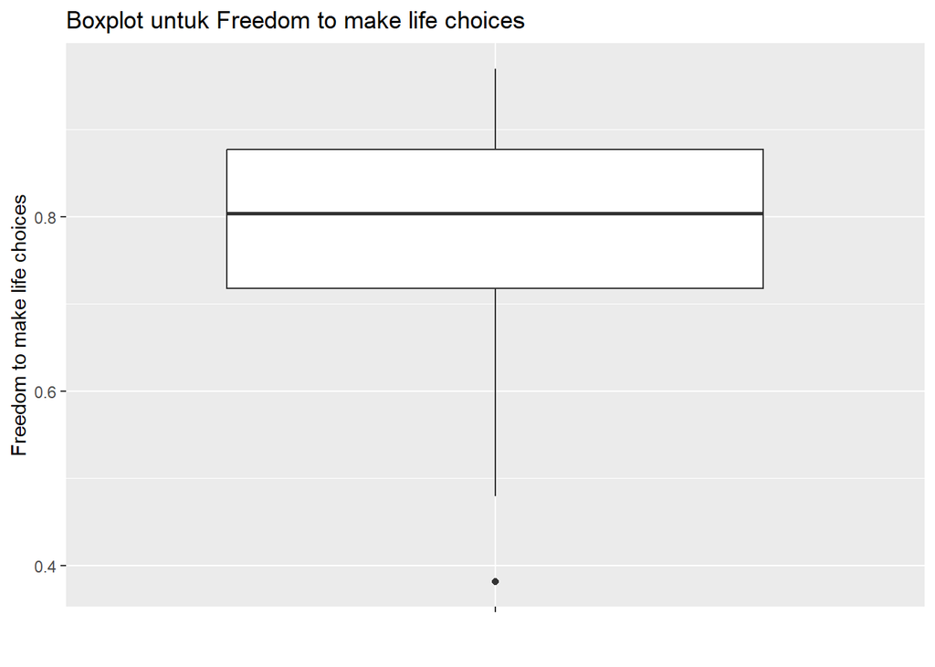

```r
# Freedom to make life choices
ggplot(data.num, aes(x = "", y = `Freedom to make life choices`)) +
  geom_boxplot() +
  labs(title = "Boxplot untuk Freedom to make life choices", x = "")
```

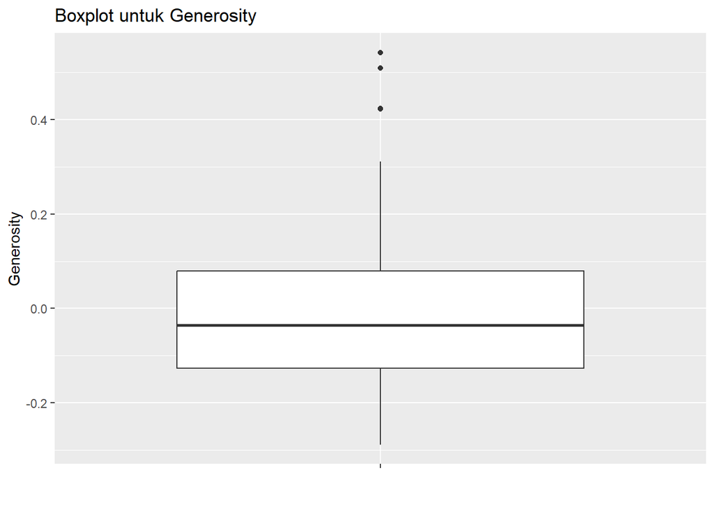

```r
# Generosity
ggplot(data.num, aes(x = "", y = `Generosity`)) +
  geom_boxplot() +
  labs(title = "Boxplot untuk Generosity", x = "")
```

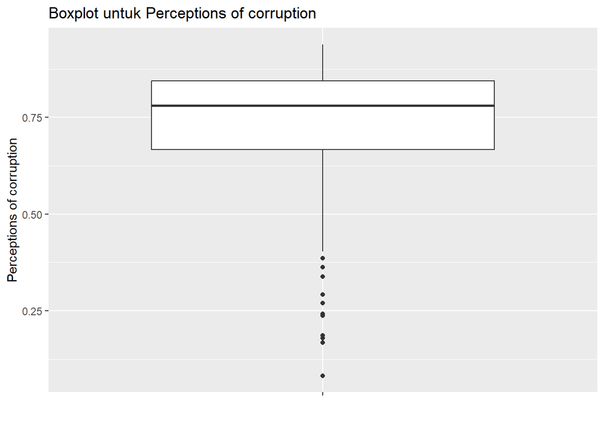

```r
# Perceptions of corruption
ggplot(data.num, aes(x = "", y = `Perceptions of corruption`)) +
  geom_boxplot() +
  labs(title = "Boxplot untuk Perceptions of corruption", x = "")
```

- Logged GDP per capita –> tidak ada outlier
- Social support –> ada 2 outlier di bawah (agak berdekatan)
- Freedom to make life choices –> ada 1 oulier di bawah (cukup jauh)
- Generosity –> ada 3 outlier di atas (2 outlier terjauh cukup berdektan)
- Perceptioin of corruption –> cukup banyak outlier di bawah (ada 1 outlier cukup jauh)

# Persiapan Data Final

```r
# Buang peubah healthy life expectancy
data.final = data.num %>% select(-`Healthy life expectancy`)
head(data.final)
```

```
## # A tibble: 6 × 5
##   `Logged GDP per capita` `Social support` Freedom to make life cho…¹ Generosity
##                     <dbl>            <dbl>                      <dbl>      <dbl>
## 1                    10.8            0.954                      0.949     -0.098
## 2                    10.9            0.954                      0.946      0.03
## 3                    11.1            0.942                      0.919      0.025
## 4                    10.9            0.983                      0.955      0.16
## 5                    10.9            0.942                      0.913      0.175
## 6                    11.1            0.954                      0.96       0.093
## # ℹ abbreviated name: ¹`Freedom to make life choices`
## # ℹ 1 more variable: `Perceptions of corruption` <dbl>
```

```r
str(data.final)
```

```
## tibble [149 × 5] (S3: tbl_df/tbl/data.frame)
##  $ Logged GDP per capita       : num [1:149] 10.8 10.9 11.1 10.9 10.9 ...
##  $ Social support              : num [1:149] 0.954 0.954 0.942 0.983 0.942 0.954 0.934 0.908 0.948 0.934 ...
##  $ Freedom to make life choices: num [1:149] 0.949 0.946 0.919 0.955 0.913 0.96 0.945 0.907 0.929 0.908 ...
##  $ Generosity                  : num [1:149] -0.098 0.03 0.025 0.16 0.175 0.093 0.086 -0.034 0.134 0.042 ...
##  $ Perceptions of corruption   : num [1:149] 0.186 0.179 0.292 0.673 0.338 0.27 0.237 0.386 0.242 0.481 ...
```

## Standarisasi Data

```r
data.final.new = scale(data.final)
summary(data.final.new)
```

```
##  Logged GDP per capita Social support    Freedom to make life choices
##  Min.   :-2.4143       Min.   :-3.0616   Min.   :-3.6141
##  1st Qu.:-0.7692       1st Qu.:-0.5635   1st Qu.:-0.6494
##  Median : 0.1181       Median : 0.1502   Median : 0.1094
##  Mean   : 0.0000       Mean   : 0.0000   Mean   : 0.0000
##  3rd Qu.: 0.8534       3rd Qu.: 0.7856   3rd Qu.: 0.7536
##  Max.   : 1.9116       Max.   : 1.4645   Max.   : 1.5742
##    Generosity      Perceptions of corruption
##  Min.   :-1.8112   Min.   :-3.6013
##  1st Qu.:-0.7359   1st Qu.:-0.3373
##  Median :-0.1385   Median : 0.2988
##  Mean   : 0.0000   Mean   : 0.0000
##  3rd Qu.: 0.6248   3rd Qu.: 0.6559
##  Max.   : 3.6980   Max.   : 1.1804
```

Semua nilai peubah data sudah dalam satu skala yang sama.

```r
# Simpan nama negara untuk label di akhir
negara = data_new$`Country name`
head(negara)
```

```
## [1] "Finland"     "Denmark"     "Switzerland" "Iceland"     "Netherlands"
## [6] "Norway"
```

## Menentukan K Optimal

Menggunakan fviz_nbclust untuk mencari jumlah gerombol (K) optimal dengan menggunakan FUNcluster = pam (K-Medoids) dan method = “silhouette” yang robust.

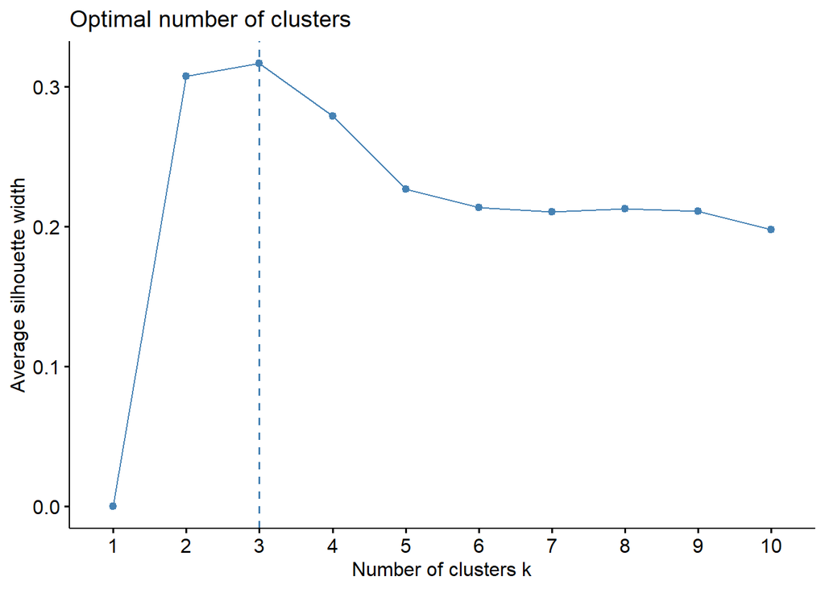

```r
# Penentuan K Optimal
set.seed(123)
plot_k_optimal = fviz_nbclust(data.final.new,
                              FUNcluster = pam, # Fungsi: K-Medoids
                              method = "silhouette") # Metode Evaluasi
plot_k_optimal
```

Terlihat dari plot bahwa K optimalnya adalah 3, maka akan ada 3 gerombol karena ketika menambahkan nilai K Average silhouette width nya mulai menurun sehingga kurang baik.

# Metode Hierarki

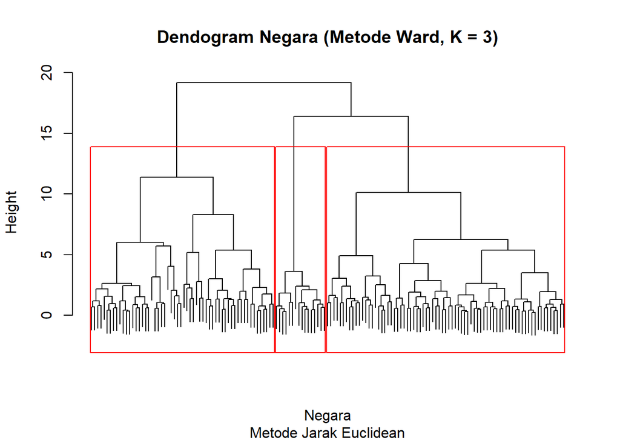

```r
# Hitung matriks jarak
euclidean = dist(data.final.new, method = "euclidean")

# Jalankan metode hierarki (Metode Ward)
set.seed(123)
hierarki = hclust(euclidean, method = "ward.D2")

# Visualisasi (Dendogram)
plot(hierarki,
     main = "Dendogram Negara (Metode Ward, K = 3)",
     xlab = "Negara",
     sub = "Metode Jarak Euclidean",
     labels = FALSE,
     cex = 0.6)
rect.hclust(hierarki, k = 3, border = "red") # Menambahkan kotak merah untuk gerombol
```

```r
# Label Keanggotaan Gerombol
label_hierarki = cutree(hierarki, k=3)
print(table(label_hierarki))
```

```
## label_hierarki
##  1  2  3
## 16 75 58
```

```r
# Daftar negara tiap gerombol
gerombol = data.frame(
  Negara = negara,
  Gerombol = label_hierarki
)
head(gerombol)
```

```
##        Negara Gerombol
## 1     Finland        1
## 2     Denmark        1
## 3 Switzerland        1
## 4     Iceland        2
## 5 Netherlands        1
## 6      Norway        1
```

```r
# Dapatkan vektor nama negara untuk setiap gerombol
negarag1 <- gerombol %>%
  filter(Gerombol == 1) %>%
  pull(Negara) # 16 negara

negarag2 <- gerombol %>%
  filter(Gerombol == 2) %>%
  pull(Negara) # 75 negara

negarag3 <- gerombol %>%
  filter(Gerombol == 3) %>%
  pull(Negara) # 58 negara

# Cari panjang maksimum (yaitu 75)
max_len <- max(length(negarag1), length(negarag2), length(negarag3))

# "Pad" (isi) vektor yang lebih pendek dengan NA agar panjangnya sama
length(negarag1) <- max_len
length(negarag2) <- max_len
length(negarag3) <- max_len

# Buat data frame (tabel) akhir
# check.names = FALSE agar nama kolom tidak diubah jadi "Gerombol.1"
tabel_hasil_hierarki <- data.frame(
  "Gerombol 1" = negarag1,
  "Gerombol 2" = negarag2,
  "Gerombol 3" = negarag3,
  check.names = FALSE
)

# Tabel daftar negara per gerombol
print("--- Tabel Anggota Gerombol (Metode Hierarki) ---")
```

```
## [1] "--- Tabel Anggota Gerombol (Metode Hierarki) ---"
```

```r
print(tabel_hasil_hierarki)
```

```
##                   Gerombol 1               Gerombol 2          Gerombol 3
## 1                    Finland                  Iceland           Guatemala
## 2                    Denmark                   Israel              Kosovo
## 3                Switzerland               Costa Rica          Uzbekistan
## 4                Netherlands           Czech Republic         El Salvador
## 5                     Norway            United States            Thailand
## 6                     Sweden                  Belgium           Nicaragua
## 7                 Luxembourg                   France            Honduras
## 8                New Zealand                  Bahrain         Philippines
## 9                    Austria                    Malta          Kyrgyzstan
## 10                 Australia Taiwan Province of China             Bolivia
## 11                   Germany     United Arab Emirates            Paraguay
## 12                    Canada             Saudi Arabia          Tajikistan
## 13                   Ireland                    Spain             Vietnam
## 14            United Kingdom                    Italy            Malaysia
```

[output cut: 61 more lines]

# Metode Non Hierarki

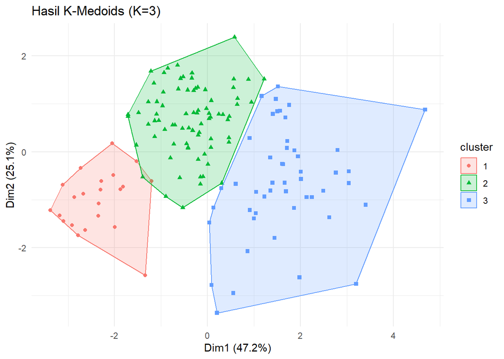

```r
# K-Medoids (pam)
set.seed(123)
model_kmedoids <- pam(data.final.new,
                        k = 3,
                        metric = "euclidean") # Gunakan data standar 'data.final.new' dan K=3

# Label model K-Medoids
label_kmedoids <- model_kmedoids$cluster

# Visualisasi
plot_kmedoids <- fviz_cluster(model_kmedoids,
                              data = data.final.new,
                              geom = "point",
                              ellipse.type = "convex") +
  ggtitle("Hasil K-Medoids (K=3)") +
  theme_minimal()

print(plot_kmedoids)
```

```r
# Membandingkan metode
tabel_silang <- table(Hierarki_Ward = label_hierarki,
                      KMedoids_pam = label_kmedoids)

print("TABEL SILANG PERBANDINGAN METODE")
```

```
## [1] "TABEL SILANG PERBANDINGAN METODE"
```

```r
print(tabel_silang)
```

```
##              KMedoids_pam
## Hierarki_Ward  1  2  3
##             1 16  0  0
##             2  5 63  7
##             3  1 15 42
```

Perbedaan ini mungkin terjadi disebabkan karena outlier yang terdapat dalam data. Metode Ward yang tidak robust terhadap outlier dan berbasis ragam yang mungkin agak terganggu dengan outlier.

Sementara metode K-Medoids yang memang robust terhadap outlier dan mengabaikan outlier tersebut sehingga memiliki batas yang berbeda si daerah yang “abu-abu”

# Profiling

Menentukan apa makna dari 3 gerombol yang dihasilkan. Di sini dipilih metode K-Medoids yang memang robust terhadap outlier secara teoritis.

```r
profiling = data.final %>% mutate (Gerombol = label_kmedoids)

# Hitung rataan tiap peubah di tiap gerombol
tabel_profil = profiling %>%
  group_by(Gerombol) %>%
  summarise_all(mean)

# Tabel Hasil profiling
print(tabel_profil)
```

```
## # A tibble: 3 × 6
##   Gerombol `Logged GDP per capita` `Social support` Freedom to make life choic…¹
##      <int>                   <dbl>            <dbl>                        <dbl>
## 1        1                   10.9             0.928                        0.909
## 2        2                    9.84            0.863                        0.802
## 3        3                    8.14            0.687                        0.723
## # ℹ abbreviated name: ¹`Freedom to make life choices`
## # ℹ 2 more variables: Generosity <dbl>, `Perceptions of corruption` <dbl>
```

```r
View(tabel_profil)
```

Dari hasil profiling Gerombol 1 merupakan gerombol dengan tingkat kebahagiaan yang paling tinggi karena Logged GDP per capita, Social support, Freedom to make life choices, dan Generosity nya memiliki nilai yang paling tinggi serta dengan nilai Perception of corruptionnya yang paling rendah.

Pada hasil profiling Gerombol 2 dan 3 ada beberapa perbedaan.

- Gerombol 2 unggul dalam 3 pilar utama yaitu : Logged GDP per capita, Social support, dan Freedom to make life choices
- Tetapi gerombol 2 nilai Generosity-nya jauh lebih kecil (-0.08) dari Gerombol 3 (0.05)

Dari hasil pertimbangan perbedaan di antara Gerombol 2 dan 3, diputuskan bahwa Gerombol 2 memiliki tingkat kebahagiaan yang lebih tinggi dari Gerombol 3 karena unggul dalam 3 pilar utama.

# Tugas Individu TPG Praktikum : Analisis Gerombol

Muth’iah Iffa Karimah

2025-11-06

# Input Data : Data World Happiness Record 2021 (kaggle)

```r
library(readr)
library(psych)
library(GPArotation)
library(factoextra)
library(dplyr)
library(cluster)
library(factoextra)
library(clusterCrit)
```

```r
library(ggplot2)
library(tidyr)
library(scales)
library(corrplot)
library(cluster)
```

```r
data = read_csv("D:\\Semester 5\\TPG\\TPG\\world-happiness-report-2021.csv")
str(data)
```

```
## spc_tbl_ [149 × 20] (S3: spec_tbl_df/tbl_df/tbl/data.frame)
##  $ Country name                              : chr [1:149] "Finland" "Denmark" "Switzerland" "Iceland" ...
##  $ Regional indicator                        : chr [1:149] "Western Europe" "Western Europe" "Western Europe" "Western Europe" ...
##  $ Ladder score                              : num [1:149] 7.84 7.62 7.57 7.55 7.46 ...
##  $ Standard error of ladder score            : num [1:149] 0.032 0.035 0.036 0.059 0.027 0.035 0.036 0.037 0.04 0.036 ...
##  $ upperwhisker                              : num [1:149] 7.9 7.69 7.64 7.67 7.52 ...
##  $ lowerwhisker                              : num [1:149] 7.78 7.55 7.5 7.44 7.41 ...
##  $ Logged GDP per capita                     : num [1:149] 10.8 10.9 11.1 10.9 10.9 ...
##  $ Social support                            : num [1:149] 0.954 0.954 0.942 0.983 0.942 0.954 0.934 0.908 0.948 0.934 ...
##  $ Healthy life expectancy                   : num [1:149] 72 72.7 74.4 73 72.4 73.3 72.7 72.6 73.4 73.3 ...
##  $ Freedom to make life choices              : num [1:149] 0.949 0.946 0.919 0.955 0.913 0.96 0.945 0.907 0.929 0.908 ...
##  $ Generosity                                : num [1:149] -0.098 0.03 0.025 0.16 0.175 0.093 0.086 -0.034 0.134 0.042 ...
##  $ Perceptions of corruption                 : num [1:149] 0.186 0.179 0.292 0.673 0.338 0.27 0.237 0.386 0.242 0.481 ...
##  $ Ladder score in Dystopia                  : num [1:149] 2.43 2.43 2.43 2.43 2.43 2.43 2.43 2.43 2.43 2.43 ...
##  $ Explained by: Log GDP per capita          : num [1:149] 1.45 1.5 1.57 1.48 1.5 ...
##  $ Explained by: Social support              : num [1:149] 1.11 1.11 1.08 1.17 1.08 ...
##  $ Explained by: Healthy life expectancy     : num [1:149] 0.741 0.763 0.816 0.772 0.753 0.782 0.763 0.76 0.785 0.782 ...
##  $ Explained by: Freedom to make life choices: num [1:149] 0.691 0.686 0.653 0.698 0.647 0.703 0.685 0.639 0.665 0.64 ...
##  $ Explained by: Generosity                  : num [1:149] 0.124 0.208 0.204 0.293 0.302 0.249 0.244 0.166 0.276 0.215 ...
##  $ Explained by: Perceptions of corruption   : num [1:149] 0.481 0.485 0.413 0.17 0.384 0.427 0.448 0.353 0.445 0.292 ...
##  $ Dystopia + residual                       : num [1:149] 3.25 2.87 2.84 2.97 2.8 ...
##  - attr(*, "spec")=
##   .. cols(
##   ..   `Country name` = col_character(),
##   ..   `Regional indicator` = col_character(),
##   ..   `Ladder score` = col_double(),
##   ..   `Standard error of ladder score` = col_double(),
##   ..   upperwhisker = col_double(),
##   ..   lowerwhisker = col_double(),
##   ..   `Logged GDP per capita` = col_double(),
##   ..   `Social support` = col_double(),
##   ..   `Healthy life expectancy` = col_double(),
##   ..   `Freedom to make life choices` = col_double(),
##   ..   Generosity = col_double(),
##   ..   `Perceptions of corruption` = col_double(),
##   ..   `Ladder score in Dystopia` = col_double(),
##   ..   `Explained by: Log GDP per capita` = col_double(),
##   ..   `Explained by: Social support` = col_double(),
##   ..   `Explained by: Healthy life expectancy` = col_double(),
##   ..   `Explained by: Freedom to make life choices` = col_double(),
##   ..   `Explained by: Generosity` = col_double(),
##   ..   `Explained by: Perceptions of corruption` = col_double(),
##   ..   `Dystopia + residual` = col_double()
##   .. )
##  - attr(*, "problems")=<externalptr>
```

```r
View(data)
```

# Eksplorasi Data

### Peubah Relevan

Memilih peubah yang relevan dengan sosial-politik-dan ekoonomi karena peubah seperti log GDP per kapita menunjukkan skor bukan peubah untuk penggerombolan.

```r
# Memilih peubah yang relevan
data_new <- data %>%
  select(`Country name`,
         `Logged GDP per capita`,
         `Social support`,
         `Healthy life expectancy`,
         `Freedom to make life choices`,
         `Generosity`,
         `Perceptions of corruption`)

# Lihat 6 baris pertama dari data baru kita
head(data_new)
```

```
## # A tibble: 6 × 7
##   `Country name` `Logged GDP per capita` `Social support` Healthy life expecta…¹
##   <chr>                            <dbl>            <dbl>                  <dbl>
## 1 Finland                           10.8            0.954                   72
## 2 Denmark                           10.9            0.954                   72.7
## 3 Switzerland                       11.1            0.942                   74.4
## 4 Iceland                           10.9            0.983                   73
## 5 Netherlands                       10.9            0.942                   72.4
## 6 Norway                            11.1            0.954                   73.3
## # ℹ abbreviated name: ¹`Healthy life expectancy`
## # ℹ 3 more variables: `Freedom to make life choices` <dbl>, Generosity <dbl>,
## #   `Perceptions of corruption` <dbl>
```

```r
View(data_new)
```

## Cek Missing Value

```r
# Menghitung jumlah data hilang di tiap kolom
colSums(is.na(data_new))
```

```
##                 Country name        Logged GDP per capita
##                            0                            0
##               Social support      Healthy life expectancy
##                            0                            0
## Freedom to make life choices                   Generosity
##                            0                            0
##    Perceptions of corruption
##                            0
```

Data sudah bersih, terlihat tidak ada missing value di tiap kolom

## Skala Peubah

Menjawab pertanyaan “Apakah perlu standarisasi?”

```r
data.num = data_new %>% select(-`Country name`) # Pengecualian kolom negara untuk dianalisis
summary(data.num) # Ringkasan statistik
```

```
##  Logged GDP per capita Social support   Healthy life expectancy
##  Min.   : 6.635        Min.   :0.4630   Min.   :48.48
##  1st Qu.: 8.541        1st Qu.:0.7500   1st Qu.:59.80
##  Median : 9.569        Median :0.8320   Median :66.60
##  Mean   : 9.432        Mean   :0.8147   Mean   :64.99
##  3rd Qu.:10.421        3rd Qu.:0.9050   3rd Qu.:69.60
##  Max.   :11.647        Max.   :0.9830   Max.   :76.95
##  Freedom to make life choices   Generosity       Perceptions of corruption
##  Min.   :0.3820               Min.   :-0.28800   Min.   :0.0820
##  1st Qu.:0.7180               1st Qu.:-0.12600   1st Qu.:0.6670
##  Median :0.8040               Median :-0.03600   Median :0.7810
##  Mean   :0.7916               Mean   :-0.01513   Mean   :0.7274
##  3rd Qu.:0.8770               3rd Qu.: 0.07900   3rd Qu.:0.8450
##  Max.   :0.9700               Max.   : 0.54200   Max.   :0.9390
```

## Outlier

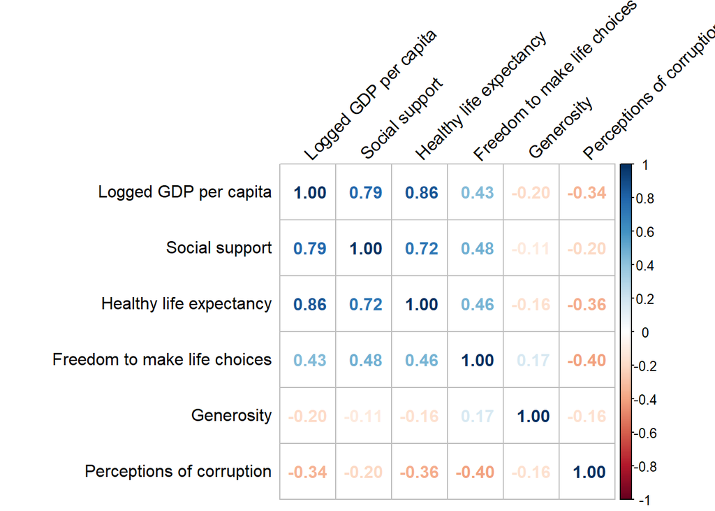

```r
# Matriks korelasi
corr = cor(data.num)

# Visualisasi
corrplot(corr, method = "number", tl.col = "black", tl.srt = 45)
```

Dalam data terlihat bahwa korelasi tertinggi antarpeubah adalah

1. **Helathy life expectancy - Logged GDP per capita = 0.86**
2. **Social support - Logged GDP per capita = 0.79**
3. **Healthy life expecancy - Social support = 0.72**

Artinya hasil matriks korelasi ini menunjukkan bahwa ada multikolinearitas pada data, perlu “membuang” salah satu peubah yang menyebabkan redudansi.

Di sini saya akan **membuang peubah “Healthy life expectancy”** karena peubah tersebut adalah hasil dari peubah “Logged GDP per capita” dan “Social support” yang mana kedua peubah ini adalah pendorong utama dari ekonomi dan sosial.

## Boxplot

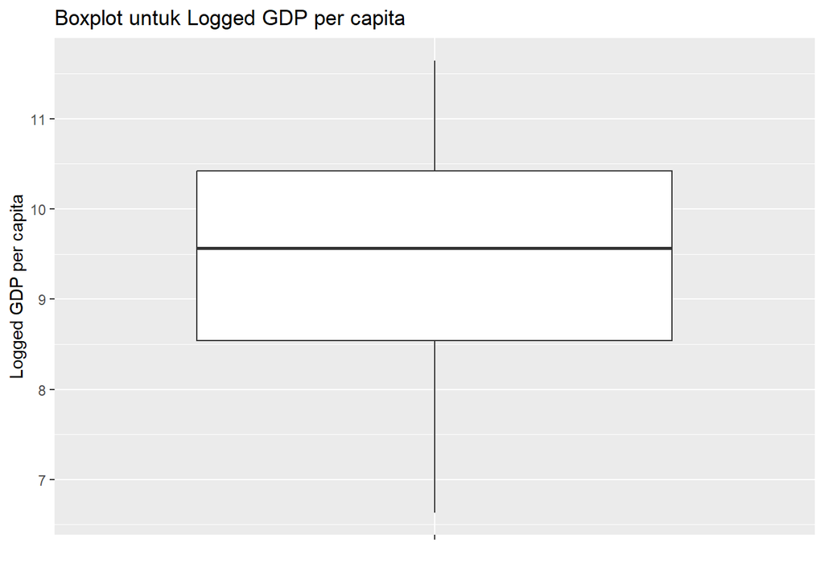

```r
# Logged GDP per capita
ggplot(data.num, aes(x = "", y = `Logged GDP per capita`)) +
  geom_boxplot() +
  labs(title = "Boxplot untuk Logged GDP per capita", x = "")
```

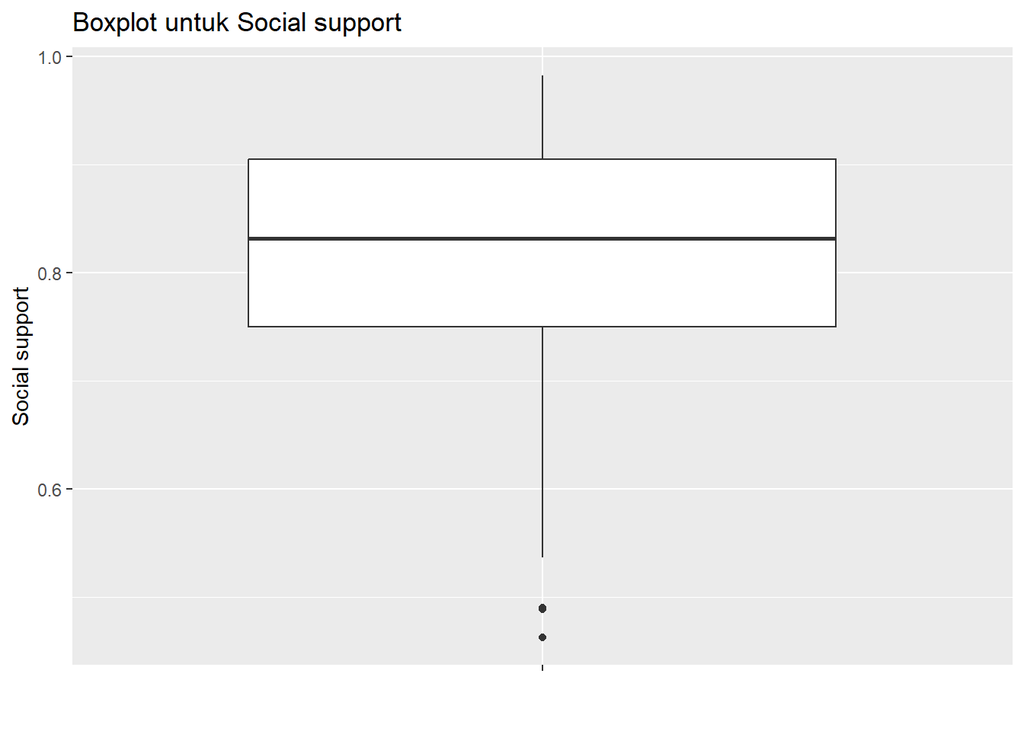

```r
# Social support
ggplot(data.num, aes(x = "", y = `Social support`)) +
  geom_boxplot() +
  labs(title = "Boxplot untuk Social support", x = "")
```

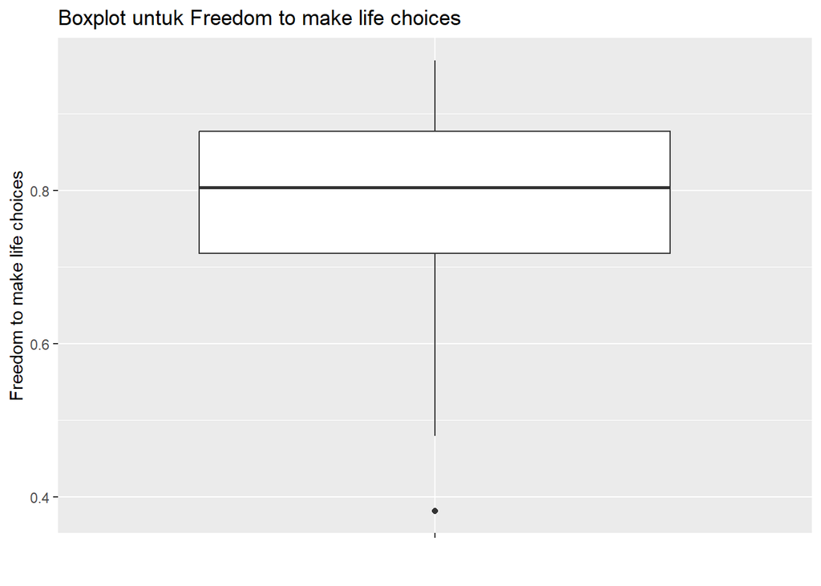

```r
# Freedom to make life choices
ggplot(data.num, aes(x = "", y = `Freedom to make life choices`)) +
  geom_boxplot() +
  labs(title = "Boxplot untuk Freedom to make life choices", x = "")
```

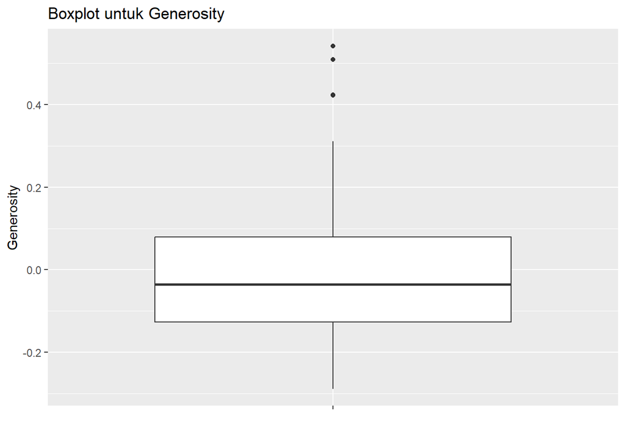

```r
# Generosity
ggplot(data.num, aes(x = "", y = `Generosity`)) +
  geom_boxplot() +
  labs(title = "Boxplot untuk Generosity", x = "")
```

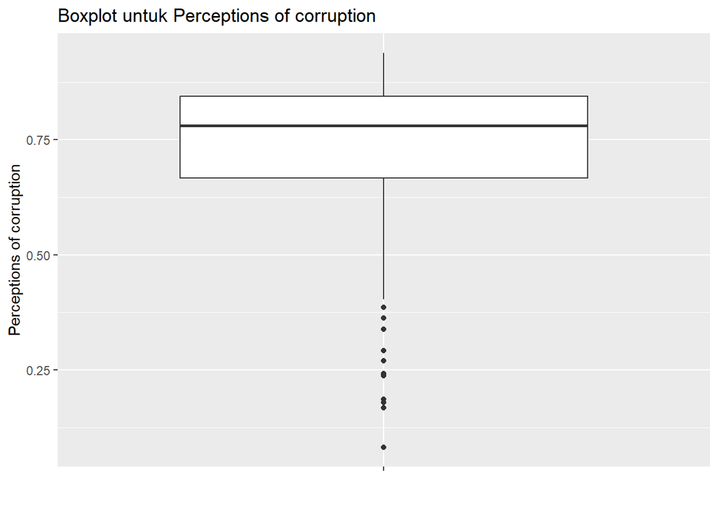

```r
# Perceptions of corruption
ggplot(data.num, aes(x = "", y = `Perceptions of corruption`)) +
  geom_boxplot() +
  labs(title = "Boxplot untuk Perceptions of corruption", x = "")
```

- Logged GDP per capita –> tidak ada outlier
- Social support –> ada 2 outlier di bawah (agak berdekatan)
- Freedom to make life choices –> ada 1 oulier di bawah (cukup jauh)
- Generosity –> ada 3 outlier di atas (2 outlier terjauh cukup berdektan)
- Perceptioin of corruption –> cukup banyak outlier di bawah (ada 1 outlier cukup jauh)

# Persiapan Data Final

```r
# Buang peubah healthy life expectancy
data.final = data.num %>% select(-`Healthy life expectancy`)
head(data.final)
```

```
## # A tibble: 6 × 5
##   `Logged GDP per capita` `Social support` Freedom to make life cho…¹ Generosity
##                     <dbl>            <dbl>                      <dbl>      <dbl>
## 1                    10.8            0.954                      0.949     -0.098
## 2                    10.9            0.954                      0.946      0.03
## 3                    11.1            0.942                      0.919      0.025
## 4                    10.9            0.983                      0.955      0.16
## 5                    10.9            0.942                      0.913      0.175
## 6                    11.1            0.954                      0.96       0.093
## # ℹ abbreviated name: ¹`Freedom to make life choices`
## # ℹ 1 more variable: `Perceptions of corruption` <dbl>
```

```r
str(data.final)
```

```
## tibble [149 × 5] (S3: tbl_df/tbl/data.frame)
##  $ Logged GDP per capita       : num [1:149] 10.8 10.9 11.1 10.9 10.9 ...
##  $ Social support              : num [1:149] 0.954 0.954 0.942 0.983 0.942 0.954 0.934 0.908 0.948 0.934 ...
##  $ Freedom to make life choices: num [1:149] 0.949 0.946 0.919 0.955 0.913 0.96 0.945 0.907 0.929 0.908 ...
##  $ Generosity                  : num [1:149] -0.098 0.03 0.025 0.16 0.175 0.093 0.086 -0.034 0.134 0.042 ...
##  $ Perceptions of corruption   : num [1:149] 0.186 0.179 0.292 0.673 0.338 0.27 0.237 0.386 0.242 0.481 ...
```

## Standarisasi Data

```r
data.final.new = scale(data.final)
summary(data.final.new)
```

```
##  Logged GDP per capita Social support    Freedom to make life choices
##  Min.   :-2.4143       Min.   :-3.0616   Min.   :-3.6141
##  1st Qu.:-0.7692       1st Qu.:-0.5635   1st Qu.:-0.6494
##  Median : 0.1181       Median : 0.1502   Median : 0.1094
##  Mean   : 0.0000       Mean   : 0.0000   Mean   : 0.0000
##  3rd Qu.: 0.8534       3rd Qu.: 0.7856   3rd Qu.: 0.7536
##  Max.   : 1.9116       Max.   : 1.4645   Max.   : 1.5742
##    Generosity      Perceptions of corruption
##  Min.   :-1.8112   Min.   :-3.6013
##  1st Qu.:-0.7359   1st Qu.:-0.3373
##  Median :-0.1385   Median : 0.2988
##  Mean   : 0.0000   Mean   : 0.0000
##  3rd Qu.: 0.6248   3rd Qu.: 0.6559
##  Max.   : 3.6980   Max.   : 1.1804
```

Semua nilai peubah data sudah dalam satu skala yang sama.

```r
# Simpan nama negara untuk label di akhir
negara = data_new$`Country name`
head(negara)
```

```
## [1] "Finland"     "Denmark"     "Switzerland" "Iceland"     "Netherlands"
## [6] "Norway"
```

## Menentukan K Optimal

Menggunakan fviz_nbclust untuk mencari jumlah gerombol (K) optimal dengan menggunakan FUNcluster = pam (K-Medoids) dan method = “silhouette” yang robust.

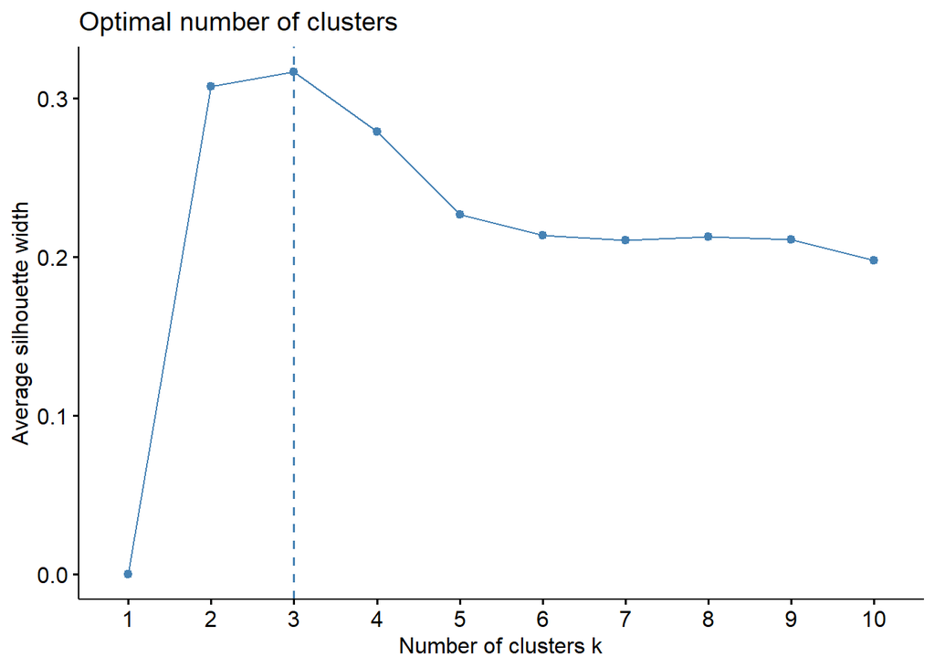

```r
# Penentuan K Optimal
set.seed(123)
plot_k_optimal = fviz_nbclust(data.final.new,
                              FUNcluster = pam, # Fungsi: K-Medoids
                              method = "silhouette") # Metode Evaluasi
plot_k_optimal
```

Terlihat dari plot bahwa K optimalnya adalah 3, maka akan ada 3 gerombol karena ketika menambahkan nilai K Average silhouette width nya mulai menurun sehingga kurang baik.

# Metode Hierarki

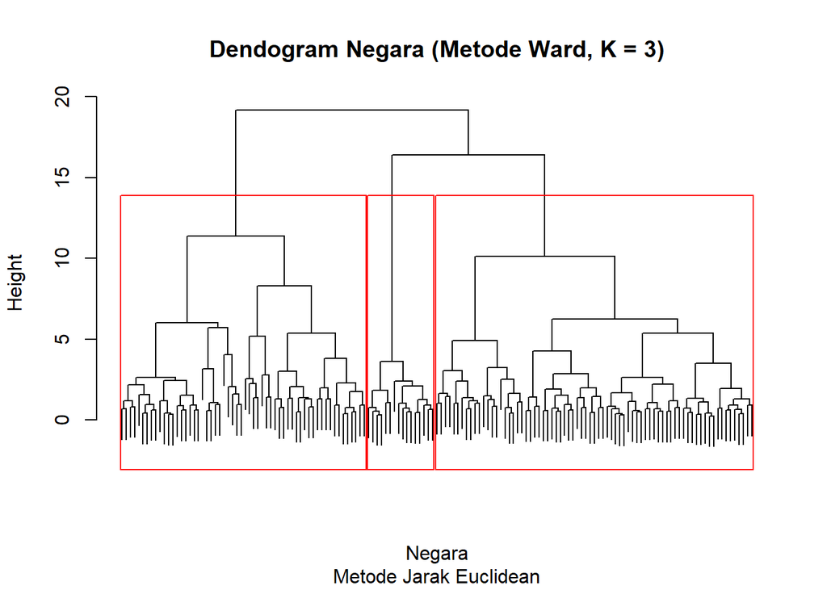

```r
# Hitung matriks jarak
euclidean = dist(data.final.new, method = "euclidean")

# Jalankan metode hierarki (Metode Ward)
set.seed(123)
hierarki = hclust(euclidean, method = "ward.D2")

# Visualisasi (Dendogram)
plot(hierarki,
     main = "Dendogram Negara (Metode Ward, K = 3)",
     xlab = "Negara",
     sub = "Metode Jarak Euclidean",
     labels = FALSE,
     cex = 0.6)
rect.hclust(hierarki, k = 3, border = "red") # Menambahkan kotak merah untuk gerombol
```

```r
# Label Keanggotaan Gerombol
label_hierarki = cutree(hierarki, k=3)
print(table(label_hierarki))
```

```
## label_hierarki
##  1  2  3
## 16 75 58
```

```r
# Daftar negara tiap gerombol
gerombol = data.frame(
  Negara = negara,
  Gerombol = label_hierarki
)
head(gerombol)
```

```
##        Negara Gerombol
## 1     Finland        1
## 2     Denmark        1
## 3 Switzerland        1
## 4     Iceland        2
## 5 Netherlands        1
## 6      Norway        1
```

```r
# Dapatkan vektor nama negara untuk setiap gerombol
negarag1 <- gerombol %>%
  filter(Gerombol == 1) %>%
  pull(Negara) # 16 negara

negarag2 <- gerombol %>%
  filter(Gerombol == 2) %>%
  pull(Negara) # 75 negara

negarag3 <- gerombol %>%
  filter(Gerombol == 3) %>%
  pull(Negara) # 58 negara

# Cari panjang maksimum (yaitu 75)
max_len <- max(length(negarag1), length(negarag2), length(negarag3))

# "Pad" (isi) vektor yang lebih pendek dengan NA agar panjangnya sama
length(negarag1) <- max_len
length(negarag2) <- max_len
length(negarag3) <- max_len

# Buat data frame (tabel) akhir
# check.names = FALSE agar nama kolom tidak diubah jadi "Gerombol.1"
tabel_hasil_hierarki <- data.frame(
  "Gerombol 1" = negarag1,
  "Gerombol 2" = negarag2,
  "Gerombol 3" = negarag3,
  check.names = FALSE
)

# Tabel daftar negara per gerombol
print("--- Tabel Anggota Gerombol (Metode Hierarki) ---")
```

```
## [1] "--- Tabel Anggota Gerombol (Metode Hierarki) ---"
```

```r
print(tabel_hasil_hierarki)
```

```
##                   Gerombol 1               Gerombol 2          Gerombol 3
## 1                    Finland                  Iceland           Guatemala
## 2                    Denmark                   Israel              Kosovo
## 3                Switzerland               Costa Rica          Uzbekistan
## 4                Netherlands           Czech Republic         El Salvador
## 5                     Norway            United States            Thailand
## 6                     Sweden                  Belgium           Nicaragua
## 7                 Luxembourg                   France            Honduras
## 8                New Zealand                  Bahrain         Philippines
## 9                    Austria                    Malta          Kyrgyzstan
## 10                 Australia Taiwan Province of China             Bolivia
## 11                   Germany     United Arab Emirates            Paraguay
## 12                    Canada             Saudi Arabia          Tajikistan
## 13                   Ireland                    Spain             Vietnam
## 14            United Kingdom                    Italy            Malaysia
```

[output cut: 61 more lines]

# Metode Non Hierarki

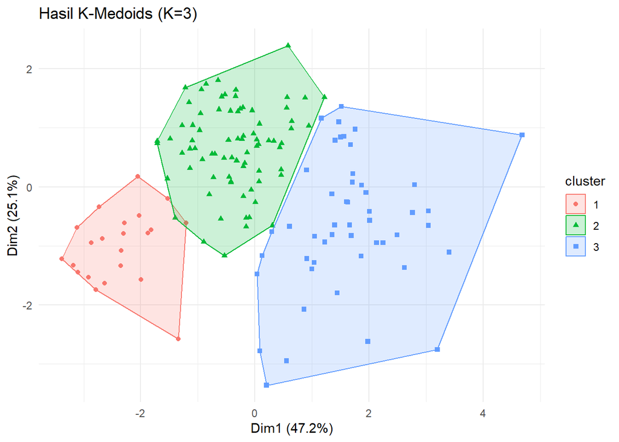

```r
# K-Medoids (pam)
set.seed(123)
model_kmedoids <- pam(data.final.new,
                        k = 3,
                        metric = "euclidean") # Gunakan data standar 'data.final.new' dan K=3

# Label model K-Medoids
label_kmedoids <- model_kmedoids$cluster

# Visualisasi
plot_kmedoids <- fviz_cluster(model_kmedoids,
                              data = data.final.new,
                              geom = "point",
                              ellipse.type = "convex") +
  ggtitle("Hasil K-Medoids (K=3)") +
  theme_minimal()

print(plot_kmedoids)
```

```r
# Membandingkan metode
tabel_silang <- table(Hierarki_Ward = label_hierarki,
                      KMedoids_pam = label_kmedoids)

print("TABEL SILANG PERBANDINGAN METODE")
```

```
## [1] "TABEL SILANG PERBANDINGAN METODE"
```

```r
print(tabel_silang)
```

```
##              KMedoids_pam
## Hierarki_Ward  1  2  3
##             1 16  0  0
##             2  5 63  7
##             3  1 15 42
```

Perbedaan ini mungkin terjadi disebabkan karena outlier yang terdapat dalam data. Metode Ward yang tidak robust terhadap outlier dan berbasis ragam yang mungkin agak terganggu dengan outlier.

Sementara metode K-Medoids yang memang robust terhadap outlier dan mengabaikan outlier tersebut sehingga memiliki batas yang berbeda si daerah yang “abu-abu”

# Profiling

Menentukan apa makna dari 3 gerombol yang dihasilkan. Di sini dipilih metode K-Medoids yang memang robust terhadap outlier secara teoritis.

```r
profiling = data.final %>% mutate (Gerombol = label_kmedoids)

# Hitung rataan tiap peubah di tiap gerombol
tabel_profil = profiling %>%
  group_by(Gerombol) %>%
  summarise_all(mean)

# Tabel Hasil profiling
print(tabel_profil)
```

```
## # A tibble: 3 × 6
##   Gerombol `Logged GDP per capita` `Social support` Freedom to make life choic…¹
##      <int>                   <dbl>            <dbl>                        <dbl>
## 1        1                   10.9             0.928                        0.909
## 2        2                    9.84            0.863                        0.802
## 3        3                    8.14            0.687                        0.723
## # ℹ abbreviated name: ¹`Freedom to make life choices`
## # ℹ 2 more variables: Generosity <dbl>, `Perceptions of corruption` <dbl>
```

```r
View(tabel_profil)
```

Dari hasil profiling Gerombol 1 merupakan gerombol dengan tingkat kebahagiaan yang paling tinggi karena Logged GDP per capita, Social support, Freedom to make life choices, dan Generosity nya memiliki nilai yang paling tinggi serta dengan nilai Perception of corruptionnya yang paling rendah.

Pada hasil profiling Gerombol 2 dan 3 ada beberapa perbedaan.

- Gerombol 2 unggul dalam 3 pilar utama yaitu : Logged GDP per capita, Social support, dan Freedom to make life choices
- Tetapi gerombol 2 nilai Generosity-nya jauh lebih kecil (-0.08) dari Gerombol 3 (0.05)

Dari hasil pertimbangan perbedaan di antara Gerombol 2 dan 3, diputuskan bahwa Gerombol 2 memiliki tingkat kebahagiaan yang lebih tinggi dari Gerombol 3 karena unggul dalam 3 pilar utama.